# What changes if no rater is excluded?

Sensitivity check of the rule that drops raters with fewer than 15 ratings

Published

November 23, 2026

The main pipeline (`../creativity-ratings-psychometrics/`) drops raters with fewer than 15 ratings (`MIN_RATINGS_PER_RATER`). This notebook fits the same GRM (same `mirt` settings, via `fit_mirt()` from `R/jrt_functions.R`) with and without that rule and compares the two (“final” = with the rule). After a trial run of the whole pipeline on all raters, the rule was kept (2026-11-23); see `all_raters_sensitivity.html` for the full comparison. It reads the same input file as the pipeline and writes nothing to the pipeline folders.

```r
PSY <- normalizePath("../creativity-ratings-psychometrics")
# jrt_functions.R finds its folder from the command line, which under quarto points
# to quarto itself; hide commandArgs so it falls back to the working directory.
owd <- setwd(PSY); commandArgs <- function(...) character(0)
source("R/jrt_functions.R"); rm(commandArgs); setwd(owd)
library(knitr)
f3 <- function(x) round(x, 3)

long <- read_csv(INPUT_CSV, show_col_types = FALSE, col_types = cols(action_id = "c", rater_id = "c", .default = "?")) %>%
  transmute(product_id = action_id, rater_id, x = as.integer(rating_numeric) - SCALE_MIN)
n_rater <- count(long, rater_id, name = "n_ratings")
rare <- n_rater$rater_id[n_rater$n_ratings < MIN_RATINGS_PER_RATER]

to_wide <- function(d) {
  w <- pivot_wider(d, names_from = rater_id, values_from = x) %>% arrange(product_id)
  m <- as.matrix(w[, rater_order(setdiff(names(w), "product_id"))]); storage.mode(m) <- "integer"
  rownames(m) <- w$product_id; m
}
wide_all <- to_wide(long)
# A rater who used one category only has no estimable GRM parameters.
one_cat <- colnames(wide_all)[apply(wide_all, 2, function(x) length(unique(na.omit(x))) < 2)]
wide_all <- wide_all[, setdiff(colnames(wide_all), one_cat)]
wide_all <- wide_all[rowSums(!is.na(wide_all)) > 0, ]

wide_fin <- to_wide(filter(long, !rater_id %in% rare))
```

```r
grm_fin <- fit_mirt(wide_fin, "graded", SE = TRUE)
grm_all <- fit_mirt(wide_all, "graded", SE = TRUE)
```

```r
fs_fin <- eap_scores(grm_fin); rownames(fs_fin) <- rownames(wide_fin)
fs_all <- eap_scores(grm_all); rownames(fs_all) <- rownames(wide_all)
```

Raters below the cut-off: R20 (13), R21 (9), R22 (2), R28 (7), R29 (1) — 32 ratings in total. R29 used a single category and cannot be modelled even without exclusion, so ‘all raters’ means all modellable raters. The all-rater model converged in 457 EM cycles.

## 1. Overall reliability

```r
kripp <- function(w) irr::kripp.alpha(t(w), method = "ordinal")$value
common <- intersect(rownames(wide_fin), rownames(wide_all))
rel_tab <- function(mod, fs, w, label) tibble(
  model = label, raters = ncol(w), ratings = sum(!is.na(w)), products = nrow(w),
  empirical_rel = empirical_rel(fs), model_based_rel = marginal_rxx(mod),
  mean_psd = mean(fs[, "SE_F1"]), mean_rel_post = mean(1 - fs[, "SE_F1"]^2),
  mean_rel_post_common = mean(1 - fs[common, "SE_F1"]^2),
  krippendorff_alpha = kripp(w))
q1 <- bind_rows(rel_tab(grm_fin, fs_fin, wide_fin, "final (≥ 15 ratings)"),
                rel_tab(grm_all, fs_all, wide_all, "all raters"))
kable(q1, digits = 3, caption = "Reliability with and without the exclusion. empirical_rel = Var(θ̂)/(Var(θ̂)+mean PSD²) (primary figure); model_based_rel = mirt::marginal_rxx (hypothetical product rated by the whole panel); rel_post = 1 − PSD² per product; _common = the products present in both models.")
```

Reliability with and without the exclusion. empirical_rel = Var(θ̂)/(Var(θ̂)+mean PSD²) (primary figure); model_based_rel = mirt::marginal_rxx (hypothetical product rated by the whole panel); rel_post = 1 − PSD² per product; _common = the products present in both models.

| model | raters | ratings | products | empirical_rel | model_based_rel | mean_psd | mean_rel_post | mean_rel_post_common | krippendorff_alpha |
| --- | --- | --- | --- | --- | --- | --- | --- | --- | --- |
| final (≥ 15 ratings) | 25 | 9831 | 3841 | 0.695 | 0.970 | 0.537 | 0.695 | 0.695 | 0.402 |
| all raters | 29 | 9862 | 3842 | 0.695 | 0.972 | 0.537 | 0.694 | 0.695 | 0.401 |

```r
th <- cbind(fin = fs_fin[common, "F1"], all = fs_all[common, "F1"])
```

The product scores of the two models correlate at r = 0.99997 (mean |Δθ| = 0.002, max 0.165). The model-based reliability rises because each extra rater adds information for a product rated by *everyone*, which no real product is.

## 2. The rarely-rating raters compared with the others

Per rater in the all-rater model: discrimination *a* (with SE), **marginal information** (expected Fisher information that one rating adds, averaged over θ ~ N(0, 1)), infit/outfit, and **agreement with the rest of the panel**: the Spearman correlation between the rater’s ratings and the EAP score the same product gets from the *other* raters only (leave-one-rater-out EAP with the all-rater parameters, products that nobody else rated are left out).

```r
theta_w <- normal_weights(THETA_GRID)
info_grid <- rater_information(grm_all, THETA_GRID)
pars <- coef(grm_all, IRTpars = TRUE, printSE = TRUE)
fit <- itemfit(grm_all, fit_stats = "infit", Theta = fs_all[, "F1", drop = FALSE], method = "EAP")
loo <- function(j) {
  rows <- which(!is.na(wide_all[, j]) & rowSums(!is.na(wide_all[, -match(j, colnames(wide_all))])) > 0)
  resp <- wide_all[rows, , drop = FALSE]; x <- resp[, j]; resp[, j] <- NA
  th <- fscores(grm_all, method = "EAP", response.pattern = resp, verbose = FALSE)[, "F1"]
  c(n_with_others = length(rows), rest_agreement = suppressWarnings(cor(x, th, method = "spearman")))
}
q2 <- tibble(rater_id = colnames(wide_all)) %>%
  mutate(n_ratings = colSums(!is.na(wide_all)),
         group = if_else(rater_id %in% rare, "< 15 ratings", "≥ 15 ratings"),
         a = sapply(rater_id, \(r) pars[[r]]["par", "a"]),
         a_se = sapply(rater_id, \(r) pars[[r]]["SE", "a"]),
         marginal_info = colSums(info_grid * theta_w),
         infit = fit$infit, outfit = fit$outfit) %>%
  bind_cols(as_tibble(t(sapply(.$rater_id, loo))))
kable(q2 %>% arrange(n_ratings), digits = 2, caption = "Raters in the all-rater GRM, sorted by number of ratings.")
```

Raters in the all-rater GRM, sorted by number of ratings.

| rater_id | n_ratings | group | a | a_se | marginal_info | infit | outfit | n_with_others | rest_agreement |
| --- | --- | --- | --- | --- | --- | --- | --- | --- | --- |
| R22 | 2 | < 15 ratings | 5.12 | 7.96 | 1.59 | 0.21 | 0.21 | 2 | 1.00 |
| R28 | 7 | < 15 ratings | 1.39 | 0.91 | 0.47 | 1.20 | 1.17 | 7 | 0.62 |
| R21 | 9 | < 15 ratings | 0.02 | 0.96 | 0.00 | 1.00 | 1.00 | 8 | 0.01 |
| R20 | 13 | < 15 ratings | 1.45 | 0.78 | 0.58 | 0.94 | 0.94 | 13 | 0.62 |
| R27 | 47 | ≥ 15 ratings | 2.99 | 0.87 | 1.93 | 0.66 | 0.65 | 47 | 0.66 |
| R30 | 47 | ≥ 15 ratings | 2.59 | 0.66 | 1.63 | 0.86 | 0.70 | 47 | 0.69 |
| R17 | 52 | ≥ 15 ratings | 1.73 | 0.51 | 0.76 | 0.93 | 0.87 | 52 | 0.60 |
| R18 | 55 | ≥ 15 ratings | 0.65 | 0.26 | 0.13 | 0.98 | 0.97 | 55 | 0.24 |
| R15 | 73 | ≥ 15 ratings | 2.73 | 0.52 | 1.98 | 0.77 | 0.69 | 73 | 0.77 |
| R26 | 136 | ≥ 15 ratings | 4.38 | 1.72 | 4.28 | 0.30 | 0.28 | 134 | 0.67 |
| R25 | 138 | ≥ 15 ratings | 3.05 | 0.45 | 2.41 | 0.75 | 0.74 | 138 | 0.74 |
| R19 | 250 | ≥ 15 ratings | 1.96 | 0.38 | 1.17 | 0.55 | 0.57 | 126 | 0.58 |
| R13 | 254 | ≥ 15 ratings | 1.50 | 0.21 | 0.65 | 0.85 | 0.85 | 249 | 0.50 |
| R12 | 264 | ≥ 15 ratings | 2.92 | 0.51 | 2.13 | 0.52 | 0.52 | 258 | 0.62 |
| R14 | 327 | ≥ 15 ratings | 2.45 | 0.45 | 1.40 | 0.54 | 0.46 | 241 | 0.53 |
| R16 | 357 | ≥ 15 ratings | 2.38 | 0.21 | 1.57 | 0.83 | 0.82 | 357 | 0.71 |
| R11 | 369 | ≥ 15 ratings | 1.95 | 0.20 | 0.99 | 0.87 | 0.83 | 365 | 0.61 |
| R10 | 383 | ≥ 15 ratings | 2.35 | 0.32 | 1.46 | 0.63 | 0.62 | 361 | 0.56 |
| R09 | 400 | ≥ 15 ratings | 0.95 | 0.15 | 0.29 | 0.87 | 0.87 | 344 | 0.36 |
| R24 | 481 | ≥ 15 ratings | 2.55 | 0.20 | 1.86 | 0.76 | 0.77 | 481 | 0.74 |
| R06 | 520 | ≥ 15 ratings | 3.16 | 0.45 | 1.77 | 0.58 | 0.45 | 475 | 0.60 |
| R08 | 522 | ≥ 15 ratings | 2.11 | 0.24 | 1.29 | 0.60 | 0.58 | 494 | 0.57 |
| R07 | 547 | ≥ 15 ratings | 1.90 | 0.16 | 0.97 | 0.82 | 0.72 | 526 | 0.64 |
| R23 | 589 | ≥ 15 ratings | 1.72 | 0.13 | 0.90 | 0.87 | 0.86 | 589 | 0.62 |
| R04 | 620 | ≥ 15 ratings | 2.05 | 0.22 | 1.17 | 0.62 | 0.58 | 489 | 0.58 |
| R05 | 633 | ≥ 15 ratings | 2.36 | 0.22 | 1.52 | 0.62 | 0.62 | 612 | 0.59 |
| R03 | 720 | ≥ 15 ratings | 1.85 | 0.17 | 0.99 | 0.75 | 0.75 | 648 | 0.53 |
| R02 | 873 | ≥ 15 ratings | 2.58 | 0.29 | 1.80 | 0.48 | 0.44 | 695 | 0.58 |
| R01 | 1174 | ≥ 15 ratings | 1.79 | 0.13 | 0.84 | 0.73 | 0.70 | 1118 | 0.52 |

```r
q2 %>% group_by(group) %>%
  summarise(raters = n(), across(c(a, marginal_info, rest_agreement), list(median = median, min = min, max = max), .names = "{.col}_{.fn}")) %>%
  kable(digits = 2, caption = "Group summary (median, min, max).")
```

Group summary (median, min, max).

| group | raters | a_median | a_min | a_max | marginal_info_median | marginal_info_min | marginal_info_max | rest_agreement_median | rest_agreement_min | rest_agreement_max |
| --- | --- | --- | --- | --- | --- | --- | --- | --- | --- | --- |
| < 15 ratings | 4 | 1.42 | 0.02 | 5.12 | 0.53 | 0.00 | 1.59 | 0.62 | 0.01 | 1.00 |
| ≥ 15 ratings | 25 | 2.35 | 0.65 | 4.38 | 1.40 | 0.13 | 4.28 | 0.60 | 0.24 | 0.77 |

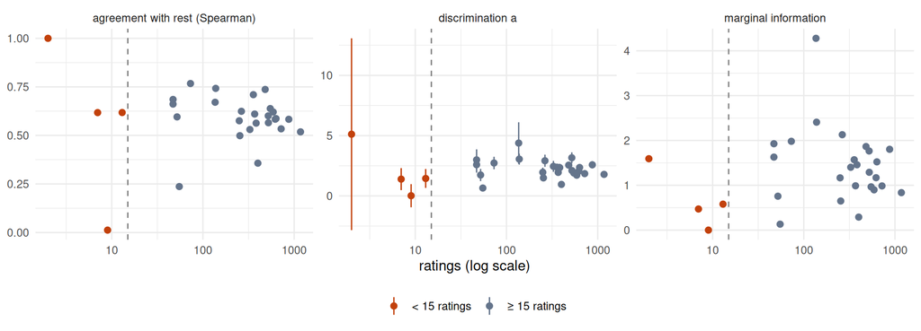

Rater discrimination (±1 SE), marginal information and rest-of-panel agreement against the number of ratings (log scale). Dashed line: the 15-rating cut-off.

```r
q2 %>% mutate(lo = a - a_se, hi = a + a_se) %>%
  pivot_longer(c(a, marginal_info, rest_agreement), names_to = "quantity") %>%
  mutate(lo = if_else(quantity == "a", lo, NA), hi = if_else(quantity == "a", hi, NA),
         quantity = recode(quantity, a = "discrimination a", marginal_info = "marginal information",
                           rest_agreement = "agreement with rest (Spearman)")) %>%
  ggplot(aes(n_ratings, value, colour = group)) +
  geom_vline(xintercept = MIN_RATINGS_PER_RATER, linetype = 2, colour = "grey50") +
  geom_linerange(aes(ymin = lo, ymax = hi), na.rm = TRUE) + geom_point(size = 2) +
  scale_x_log10() + scale_colour_manual(values = c("#c2410c", "#64748b")) +
  facet_wrap(~quantity, scales = "free_y") + labs(x = "ratings (log scale)", y = NULL, colour = NULL) +
  theme_minimal(base_size = 11) + theme(legend.position = "bottom")
```

## 3. Products rated by the rarely-rating raters

For every product that a rater below the cut-off rated: its posterior SD and rel<sub>post</sub> = 1 − PSD² in the final model (without that rating) and in the all-rater model (with it), plus the Fisher information that the extra rating contributes at the product’s θ̂. Adding a rating can only add Fisher information at fixed parameters, but the posterior SD can still grow if the rating conflicts with the others. As a baseline, the same change is shown for all other products (pure re-estimation drift, because their data did not change).

```r
rare_in <- intersect(rare, colnames(wide_all))
rare_rows <- rownames(wide_all)[rowSums(!is.na(wide_all[, rare_in, drop = FALSE])) > 0]
# Fisher information of the rare raters' ratings at each product's theta-hat (products x rare raters)
info_rare <- rowSums(rater_information(grm_all, fs_all[rare_rows, "F1"])[, rare_in, drop = FALSE] *
                       !is.na(wide_all[rare_rows, rare_in, drop = FALSE]))
names(info_rare) <- rare_rows
prod <- tibble(product_id = rownames(wide_all)) %>%
  mutate(rated_by_rare = product_id %in% rare_rows,
         n_all = rowSums(!is.na(wide_all)),
         n_fin = unname(rowSums(!is.na(wide_fin))[product_id]),
         theta_fin = fs_fin[match(product_id, rownames(fs_fin)), "F1"], theta_all = fs_all[product_id, "F1"],
         psd_fin = fs_fin[match(product_id, rownames(fs_fin)), "SE_F1"], psd_all = fs_all[product_id, "SE_F1"],
         rel_fin = 1 - psd_fin^2, rel_all = 1 - psd_all^2, d_rel = rel_all - rel_fin)
prod_rare <- prod %>% filter(rated_by_rare) %>%
  mutate(info_from_rare = info_rare[product_id],
         raters = sapply(product_id, \(p) paste(colnames(wide_all)[!is.na(wide_all[p, ])], collapse = ";")))
prod %>% filter(!is.na(n_fin)) %>% group_by(rated_by_rare) %>%
  summarise(products = n(), mean_rel_fin = mean(rel_fin), mean_rel_all = mean(rel_all),
            mean_d_rel = mean(d_rel), min_d_rel = min(d_rel), max_d_rel = max(d_rel),
            share_rel_lower = mean(d_rel < -1e-4), mean_abs_d_theta = mean(abs(theta_all - theta_fin))) %>%
  kable(digits = 3, caption = "Change in per-product reliability (all-rater minus final model), products present in both models.")
```

Change in per-product reliability (all-rater minus final model), products present in both models.

| rated_by_rare | products | mean_rel_fin | mean_rel_all | mean_d_rel | min_d_rel | max_d_rel | share_rel_lower | mean_abs_d_theta |
| --- | --- | --- | --- | --- | --- | --- | --- | --- |
| FALSE | 3813 | 0.693 | 0.693 | 0.000 | -0.005 | 0.013 | 0.543 | 0.001 |
| TRUE | 28 | 0.890 | 0.897 | 0.008 | -0.004 | 0.062 | 0.071 | 0.055 |

1 product(s) were rated *only* by raters below the cut-off and are therefore absent from the final model; in the all-rater model they get rel<sub>post</sub> = 0.

```r
prod_rare %>% arrange(d_rel) %>%
  transmute(product = substr(product_id, 1, 8), raters, n_fin, n_all, theta_fin, theta_all,
            rel_fin, rel_all, d_rel, info_from_rare) %>%
  kable(digits = 3, caption = "Each product rated by a rater below the cut-off (sorted by the change in rel_post).")
```

Each product rated by a rater below the cut-off (sorted by the change in rel_post).

| product | raters | n_fin | n_all | theta_fin | theta_all | rel_fin | rel_all | d_rel | info_from_rare |
| --- | --- | --- | --- | --- | --- | --- | --- | --- | --- |
| 12318d36 | R01;R05;R10;R16;R23;R24;R28;R30 | 7 | 8 | -0.024 | -0.189 | 0.886 | 0.882 | -0.004 | 0.434 |
| 4e4b88e5 | R03;R05;R07;R11;R18;R21;R23;R30 | 7 | 8 | 0.179 | 0.174 | 0.897 | 0.895 | -0.002 | 0.000 |
| 3031156e | R01;R04;R07;R08;R11;R21;R23 | 6 | 7 | 0.238 | 0.240 | 0.870 | 0.870 | 0.000 | 0.000 |
| 08bff696 | R01;R03;R04;R06;R07;R11;R13;R16;R17;R21;R23 | 10 | 11 | -0.008 | -0.009 | 0.917 | 0.917 | 0.000 | 0.000 |
| 1575f28a | R01;R03;R04;R05;R06;R07;R11;R15;R16;R21;R23 | 10 | 11 | -0.259 | -0.261 | 0.897 | 0.898 | 0.000 | 0.000 |
| 2ea4c4ec | R01;R06;R07;R11;R15;R16;R21;R23;R24 | 8 | 9 | 0.657 | 0.659 | 0.925 | 0.925 | 0.000 | 0.000 |
| 02b5202c | R01;R03;R07;R11;R15;R16;R21;R23;R24 | 8 | 9 | -1.374 | -1.372 | 0.889 | 0.889 | 0.000 | 0.000 |
| 02192f8c | R01;R03;R04;R05;R06;R07;R11;R13;R16;R20;R23;R24;R27 | 12 | 13 | 0.643 | 0.580 | 0.952 | 0.953 | 0.001 | 0.649 |
| 05e74a4c | R01;R03;R04;R05;R06;R07;R11;R13;R15;R18;R20;R21;R23;R24;R25;R30 | 14 | 16 | 0.654 | 0.678 | 0.955 | 0.957 | 0.001 | 0.650 |
| 283ef6cd | R03;R05;R07;R10;R16;R18;R20;R23;R24;R25;R27 | 10 | 11 | -0.986 | -0.886 | 0.931 | 0.933 | 0.002 | 0.549 |
| cb9e1aa1 | R01;R04;R07;R08;R11;R15;R16;R20;R21;R23;R24 | 9 | 11 | 1.270 | 1.329 | 0.931 | 0.934 | 0.003 | 0.624 |
| 27ac7af9 | R02;R05;R07;R11;R16;R18;R20;R23 | 7 | 8 | -0.382 | -0.476 | 0.890 | 0.893 | 0.003 | 0.618 |
| 17161f4c | R01;R02;R07;R09;R11;R15;R20;R23;R24 | 8 | 9 | 1.088 | 1.160 | 0.922 | 0.925 | 0.003 | 0.638 |
| 66669be2 | R02;R07;R09;R11;R15;R16;R17;R20;R23;R24 | 9 | 10 | 0.145 | 0.107 | 0.932 | 0.936 | 0.003 | 0.645 |
| 06f8484e | R03;R05;R06;R13;R15;R17;R20;R23;R24 | 8 | 9 | -1.025 | -1.078 | 0.895 | 0.899 | 0.004 | 0.501 |
| 01e845f6 | R07;R09;R11;R14;R15;R19;R20;R23;R24 | 8 | 9 | -1.548 | -1.596 | 0.856 | 0.861 | 0.005 | 0.343 |
| 04b80b65 | R03;R05;R06;R13;R24;R28 | 5 | 6 | 0.926 | 0.883 | 0.902 | 0.907 | 0.005 | 0.484 |
| 205e880f | R05;R07;R10;R11;R16;R18;R20;R23;R24 | 8 | 9 | -0.110 | -0.088 | 0.912 | 0.918 | 0.006 | 0.641 |
| 0deb66f0 | R03;R05;R06;R13;R20;R23;R24 | 6 | 7 | 0.986 | 0.920 | 0.891 | 0.899 | 0.008 | 0.648 |
| 775790fd | R01;R03;R12;R23;R24;R28 | 5 | 6 | -0.611 | -0.568 | 0.864 | 0.873 | 0.009 | 0.478 |
| 0eabb1a9 | R03;R05;R06;R13;R15;R20;R23;R25 | 7 | 8 | 0.796 | 0.745 | 0.891 | 0.901 | 0.010 | 0.650 |
| 4fcf108b | R07;R09;R11;R23;R27;R28 | 5 | 6 | 2.139 | 2.191 | 0.857 | 0.868 | 0.010 | 0.340 |
| 95bb17b2 | R07;R09;R16;R23;R24;R28 | 5 | 6 | 1.789 | 1.861 | 0.841 | 0.852 | 0.011 | 0.422 |
| 0c555092 | R03;R05;R06;R13;R22;R23;R24;R27;R30 | 8 | 9 | 0.473 | 0.370 | 0.928 | 0.943 | 0.015 | 4.027 |
| a46424df | R03;R06;R07;R11;R17;R20;R23;R25 | 7 | 8 | -0.769 | -0.677 | 0.875 | 0.891 | 0.015 | 0.591 |
| 4d82d50f | R01;R07;R10;R11;R23;R24;R28 | 6 | 7 | -1.431 | -1.285 | 0.799 | 0.819 | 0.020 | 0.567 |
| 26cf6395 | R01;R07;R08;R11;R15;R18;R22;R23;R24 | 8 | 9 | 0.882 | 0.988 | 0.908 | 0.931 | 0.023 | 3.396 |
| 63b7db1f | R07;R09;R11;R23;R28 | 4 | 5 | -1.367 | -1.394 | 0.698 | 0.760 | 0.062 | 0.572 |
| 22e6e349 | R21 | NA | 1 | NA | -0.015 | NA | 0.000 | NA | 0.000 |

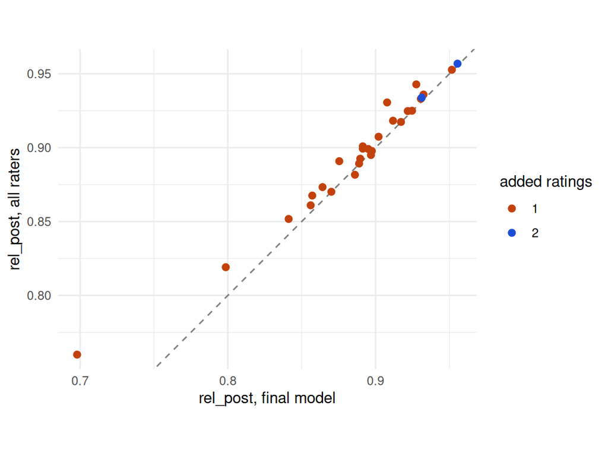

Per-product rel_post without (final model) and with (all-rater model) the ratings of the raters below the cut-off. Points above the diagonal gain reliability.

```r
ggplot(prod_rare %>% filter(!is.na(n_fin)), aes(rel_fin, rel_all, colour = factor(n_all - n_fin))) +
  geom_abline(linetype = 2, colour = "grey50") + geom_point(size = 2) +
  scale_colour_manual(values = c("1" = "#c2410c", "2" = "#1d4ed8", "3" = "#15803d")) +
  coord_equal() + labs(x = "rel_post, final model", y = "rel_post, all raters", colour = "added ratings") +
  theme_minimal(base_size = 11)
```

## Answers

*Filled in from the output above; see the tables for the exact values.*

1. **Overall reliability** barely moves: empirical marginal reliability 0.695 (final) vs 0.695 (all raters); mean rel<sub>post</sub> over the common products 0.695 vs 0.695; Krippendorff’s α 0.402 vs 0.401. The model-based (full-panel) value goes from 0.970 to 0.972 only because the hypothetical full panel gets bigger.
2. **Raters below the cut-off** (median over raters, < 15 vs ≥ 15 ratings): discrimination a = 1.42 vs 2.35, marginal information 0.53 vs 1.40, rest-of-panel agreement 0.62 vs 0.60. Their discrimination SEs are large (see table), so their individual parameters are poorly determined, which was the reason for the rule.
3. **Products they rated** (28 present in both models): mean rel<sub>post</sub> 0.890 without vs 0.897 with their ratings (mean change +0.008; 2 of 28 products lose reliability, largest loss -0.004). Products not touched by these raters change by a mean of -0.0003 (re-estimation drift).
4. **Notes.** The products these raters saw are densely rated (median 8 ratings in the final model vs 2 overall), so one extra rating changes little. Individually: R21 (9 ratings) a = 0.02, SE 0.96, rest agreement 0.01; R28 (7 ratings) a = 1.39, SE 0.91, rest agreement 0.62; R20 (13 ratings) a = 1.45, SE 0.78, rest agreement 0.62; R22 (2 ratings) a = 5.12, SE 7.96, rest agreement 1.00. The product rated only by R21 gets rel<sub>post</sub> = 0.000 in the all-rater model, i.e. no usable score.